# IE 360 - HW 3

Irmak Dai

June 6, 2021

# 1 Introduction & Problem Description

The aim of this homework to predict tomorrow’s hourly electricity consumption of Turkey. The consumption series is available on [EPIAS](https://seffaflik.epias.com.tr/transparency/tuketim/gerceklesen-tuketim/gercek-zamanli-tuketim.xhtml).

The time period of 01.01.2016-20.05.2021 is used.

Firstly, a few approaches should be used to make electricity consumption data as stationary as possible. Then, autoregressive models and moving average models will be compared.

# 2 Initial Processing

Loading the packages:

```r
library(zoo)
library(lubridate)
library(tidyverse)
library(scales)
library(tsibble)
library(urca)
library(forecast)
Sys.setlocale("LC_TIME", "English")
```

Importing the data:

```r
raw_data <- read.csv("C:/Users/Asus/Desktop/Spring 2021/IE 360/HW3/RealTimeConsumption-01012016-20052021.csv")
head(raw_data)
```

```
##         Date  Hour Consumption..MWh.
## 1 01.01.2016 00:00         26,277.24
## 2 01.01.2016 01:00         24,991.82
## 3 01.01.2016 02:00         23,532.61
## 4 01.01.2016 03:00         22,464.78
## 5 01.01.2016 04:00         22,002.91
## 6 01.01.2016 05:00         21,957.08
```

Manipulation and type adjustments:

```r
hourly <- raw_data %>%
  mutate(date_hour=paste(Date,Hour,sep = " ")) %>%
  mutate(date=as.POSIXct(date_hour,format="%d.%m.%Y %H:%M"),consumption=as.numeric(gsub(",","",Consumption..MWh.))) %>%
  select(date,consumption)
```

# 3 Analysis

We have hourly data. That means we may have multiple types of seasonality: hourly, daily, weekly, monthly, etc. For example; consumption is expected to be higher during the working hours than at night. Also, on the weekends we expect a lower electricity consumption, considering the electricity usage in factories. Consumption also may depend on the season of the year, or public holidays.

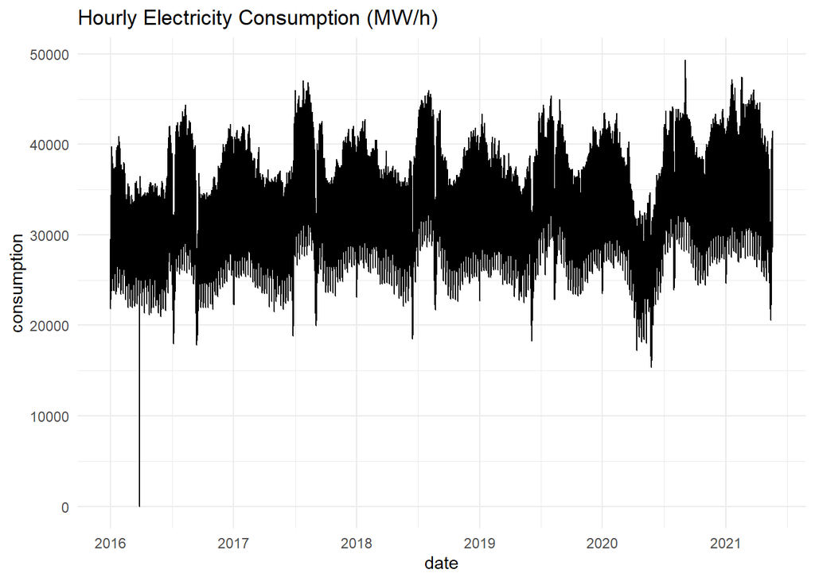

```r
ggplot(hourly,aes(x=date,y=consumption))+
  geom_line()+
  theme_minimal()+
  scale_x_datetime(breaks = date_breaks("1 year"), date_labels = "%Y")+
  labs(title="Hourly Electricity Consumption (MW/h)")
```

Key observations:

- Data has many ups and downs.
- The decrease in the first half of 2020 is probably due to Covid-19 lockdowns, when factories stopped working.
- Variation around the trend does not vary much with the level of time series; additive decomposition is a better choice to use.
- We see the effect of religious holidays in each year.
- Electricity consumption increases in the summer.
- There is a slight increasing trend in the data.
- There is an outlier in the first half of 2016, which might be an error in the data, or a country-wide power cut. I will remove the outlier and assign the mean value of the previous and following observation.

Dealing with the outlier:

```r
i <- which.min(hourly$consumption)
hourly[i,'consumption'] <- mean(c(hourly[i-1,'consumption'],hourly[i+1,'consumption']))
```

Outlier-removed time series data:

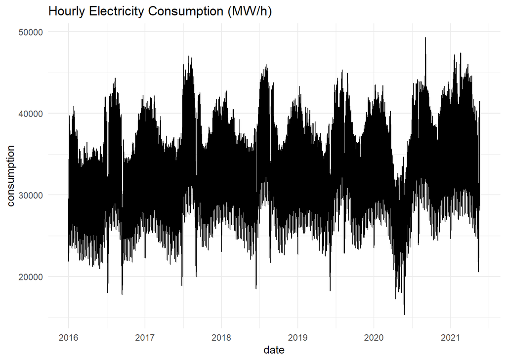

```r
ggplot(hourly,aes(x=date,y=consumption))+
  geom_line()+
  theme_minimal()+
  scale_x_datetime(breaks = date_breaks("1 year"), date_labels = "%Y")+
  labs(title="Hourly Electricity Consumption (MW/h)")
```

Apparently, data is not stationary. Let’s also check the autocorrelation plot and KPSS test.

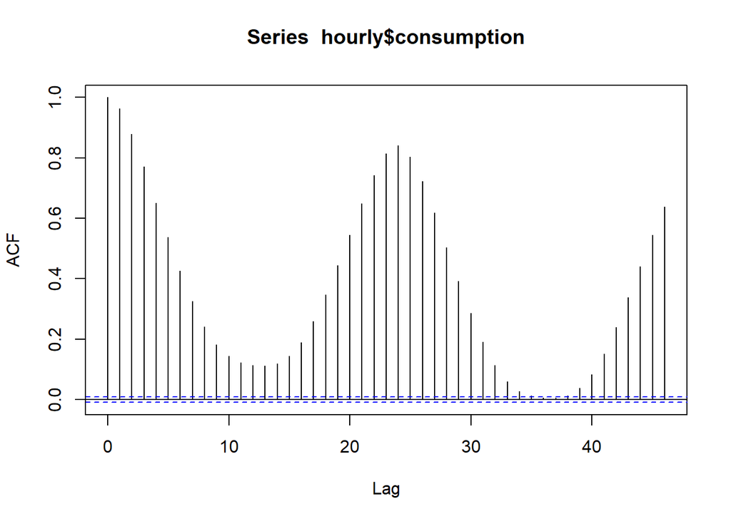

```r
acf(hourly$consumption)
```

We see a very high correlation in lag 24.

```r
hourly$consumption %>%
  ur.kpss()%>%
  summary()
```

```
##
## #######################
## # KPSS Unit Root Test #
## #######################
##
## Test is of type: mu with 18 lags.
##
## Value of test-statistic is: 12.6757
##
## Critical value for a significance level of:
##                 10pct  5pct 2.5pct  1pct
## critical values 0.347 0.463  0.574 0.739
```

The null hypothesis is the stationarity of data. Test statistic is far beyond the critical value, reject the null hypothesis and conclude that data is not stationary.

## 3.1 Task 1

### 3.1.1 Hourly decomposition

```r
ts_hourly <- ts(hourly$consumption, frequency = 24)
```

In our previous analysis, we decided that additive model would be a greater choice for this time series. Let’s use `decompose()` function to decompose the series into trend, seasonal, and random component.

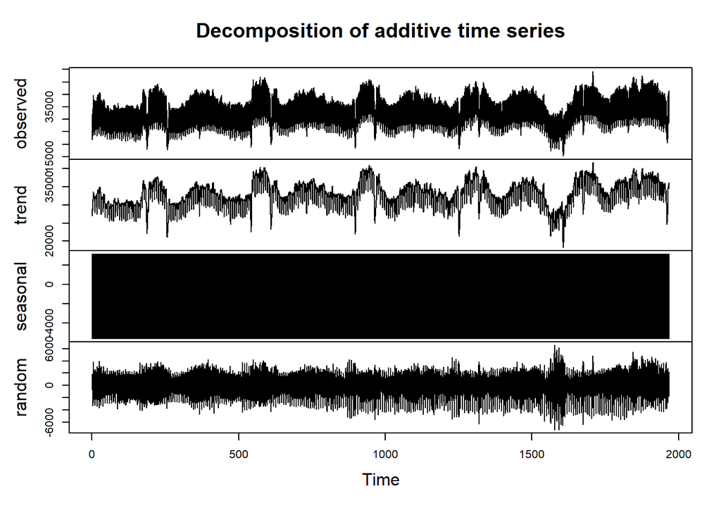

```r
decomposed_hourly <- decompose(ts_hourly, type="additive")
plot(decomposed_hourly)
```

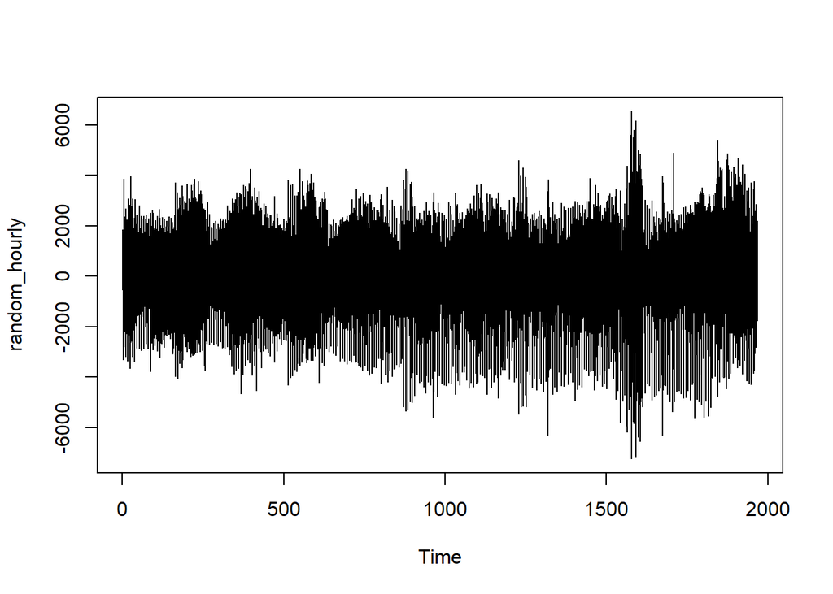

```r
random_hourly <- decomposed_hourly$random
plot(random_hourly)
```

Mean is quite constant, but variance is slightly increasing. Let’s look at autocorrelation functions:

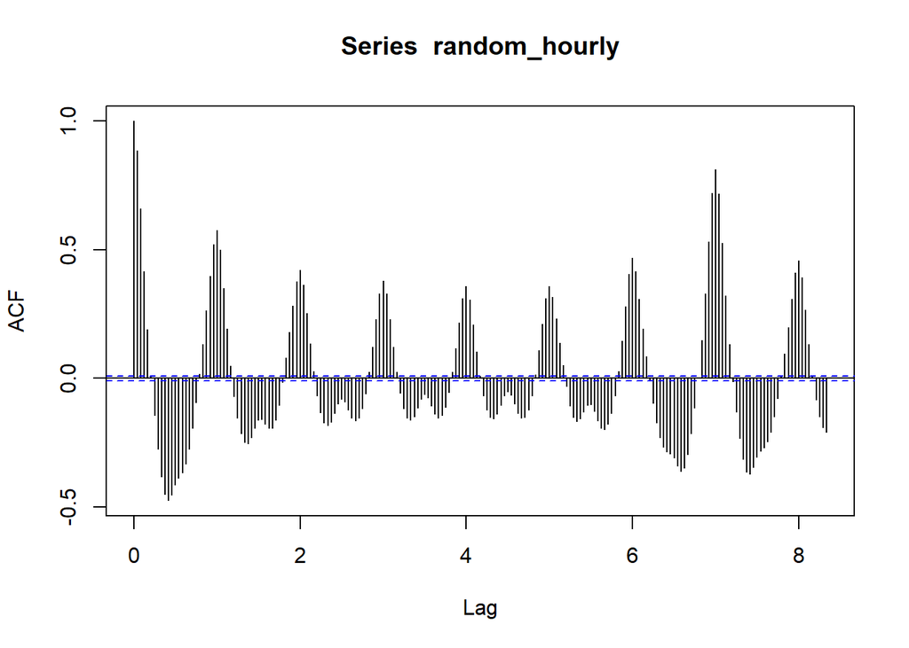

```r
acf(random_hourly, na.action = na.pass, lag.max = 200)
```

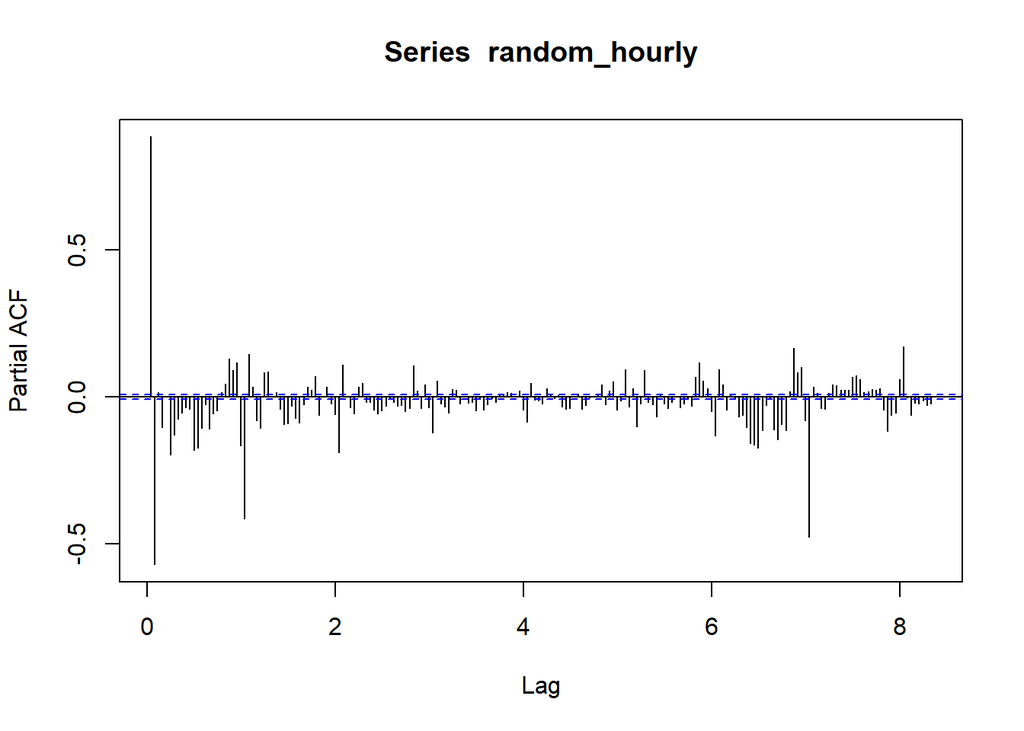

```r
pacf(random_hourly, na.action = na.pass, lag.max = 200)
```

PACF removes the effects which are already explained by previous lags. But we still see relatively high autocorrelation in lag 168 (`24*7`) in PACF, and also in ACF. That indicates that the consumption values in the same days of the weeks are correlated.

```r
random_hourly %>%
  ur.kpss() %>%
  summary()
```

```
##
## #######################
## # KPSS Unit Root Test #
## #######################
##
## Test is of type: mu with 18 lags.
##
## Value of test-statistic is: 3e-04
##
## Critical value for a significance level of:
##                 10pct  5pct 2.5pct  1pct
## critical values 0.347 0.463  0.574 0.739
```

Test statistic is very low, which supports the stationarity of data. But also there is autocorrelation in the random component, it is not sensible to use this frequency considering we have other options.

### 3.1.2 Daily decomposition

```r
daily <- hourly %>%
  group_by(date(date)) %>%
  summarise(consumption=mean(consumption)) %>%
  rename(date='date(date)')
```

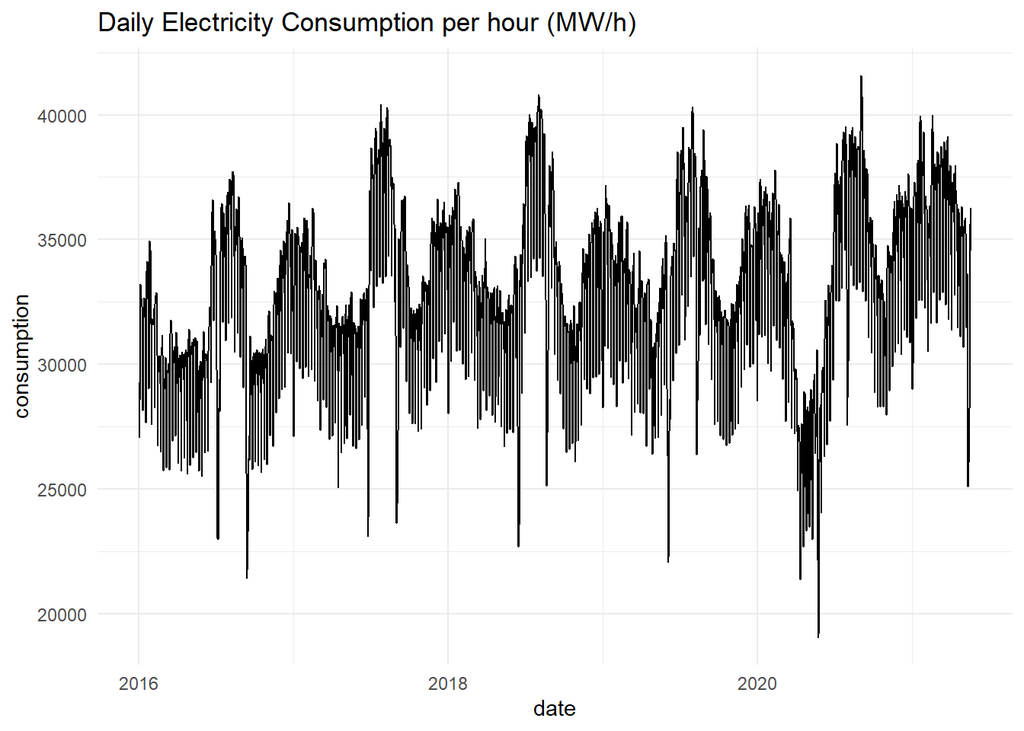

```r
ggplot(daily,aes(x=date,y=consumption))+
  geom_line()+
  theme_minimal()+
  labs(title="Daily Electricity Consumption per hour (MW/h)")
```

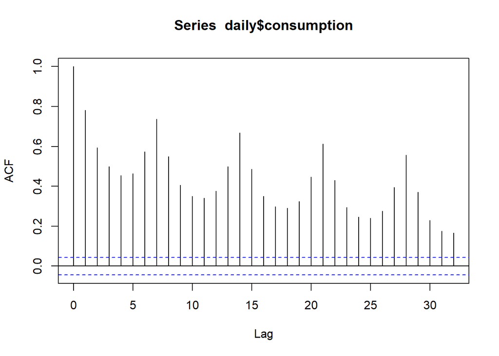

```r
acf(daily$consumption)
```

We see high autocorrelation in lag 7, which is not surprising.

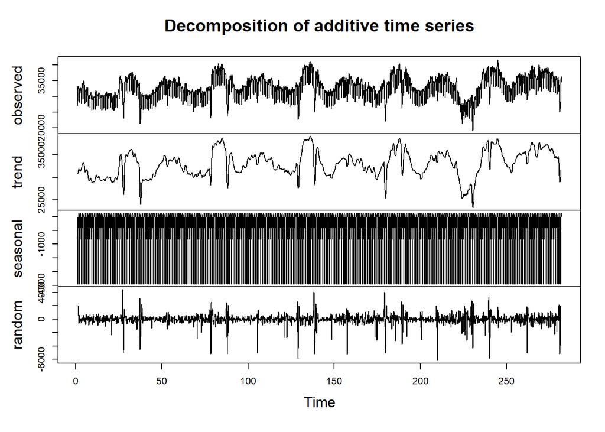

```r
ts_daily <- ts(daily$consumption, frequency = 7)
decomposed_daily <- decompose(ts_daily, type = "additive")
plot(decomposed_daily)
```

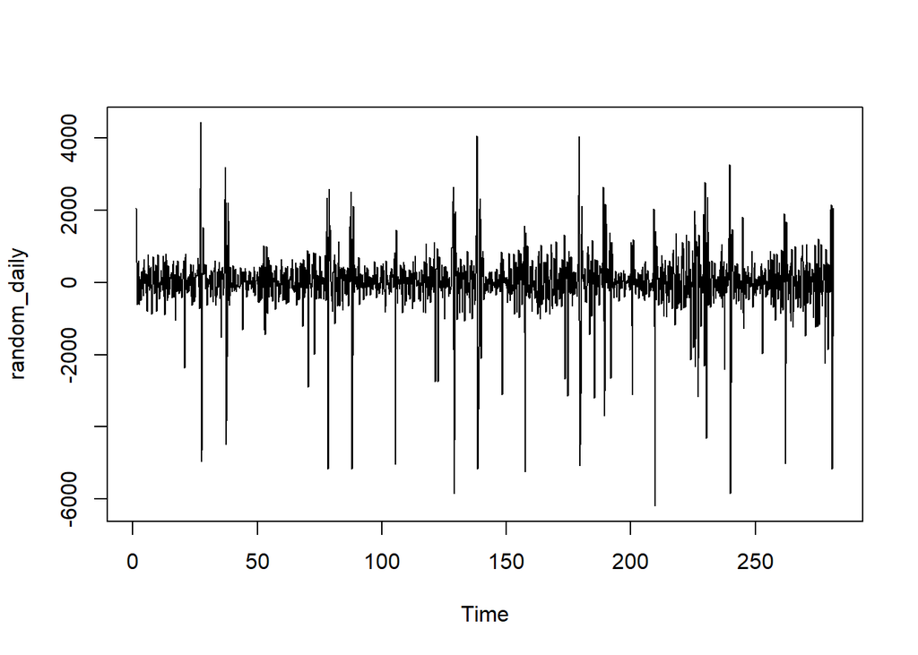

```r
random_daily <- decomposed_daily$random
plot(random_daily)
```

Constant mean assumption is satisfied. Variance does not change much over time.

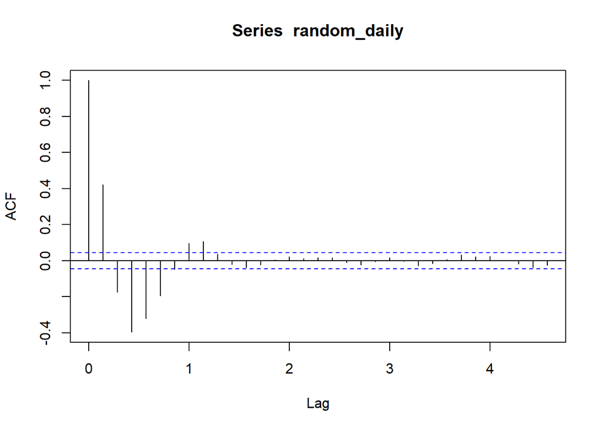

```r
acf(random_daily, na.action = na.pass)
```

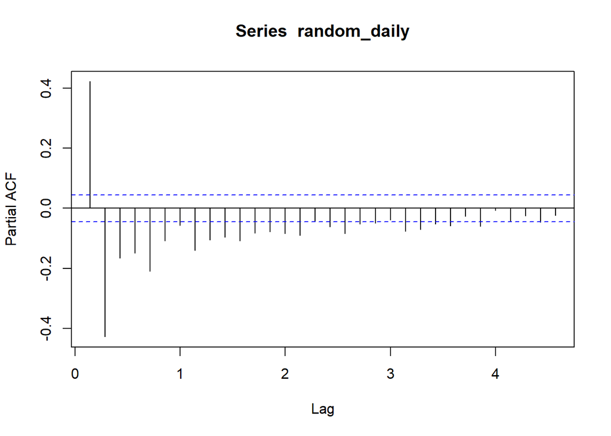

```r
pacf(random_daily, na.action = na.pass)
```

```r
random_daily %>%
  ur.kpss() %>%
  summary()
```

```
##
## #######################
## # KPSS Unit Root Test #
## #######################
##
## Test is of type: mu with 8 lags.
##
## Value of test-statistic is: 0.0067
##
## Critical value for a significance level of:
##                 10pct  5pct 2.5pct  1pct
## critical values 0.347 0.463  0.574 0.739
```

Stationarity is not rejected by this test.

### 3.1.3 Weekly decomposition

```r
weekly <- daily %>%
  group_by(yearweek(date)) %>%
  summarise(consumption=mean(consumption)) %>%
  rename(yearweek='yearweek(date)')
```

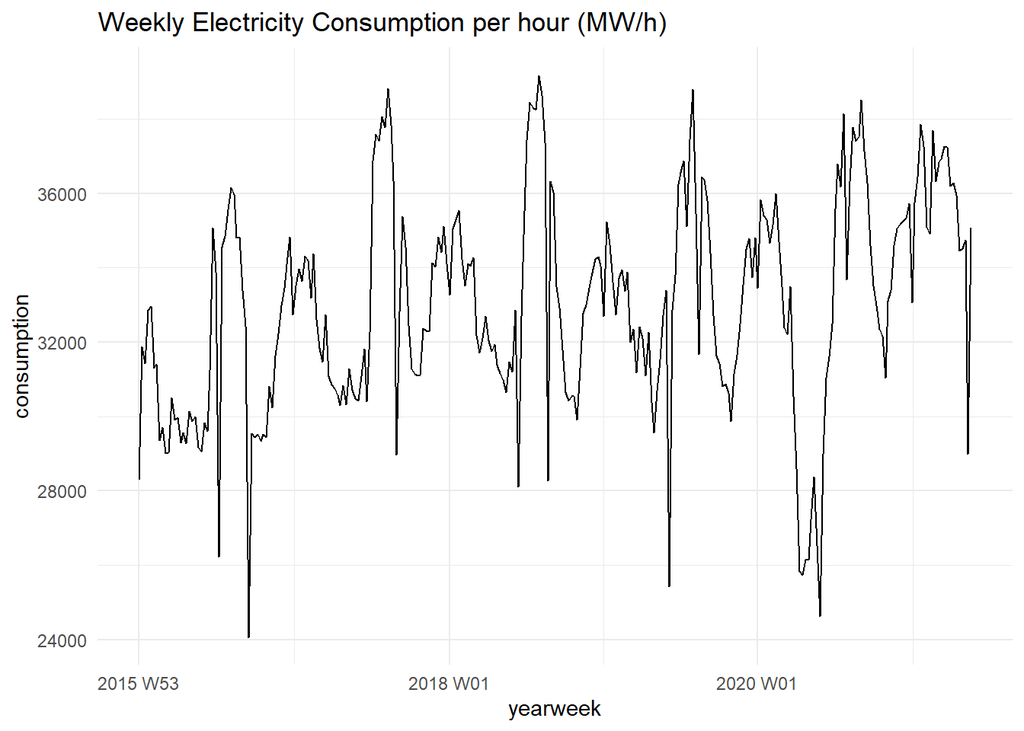

```r
ggplot(weekly,aes(x=yearweek,y=consumption))+
  geom_line()+
  theme_minimal()+
  labs(title="Weekly Electricity Consumption per hour (MW/h)")
```

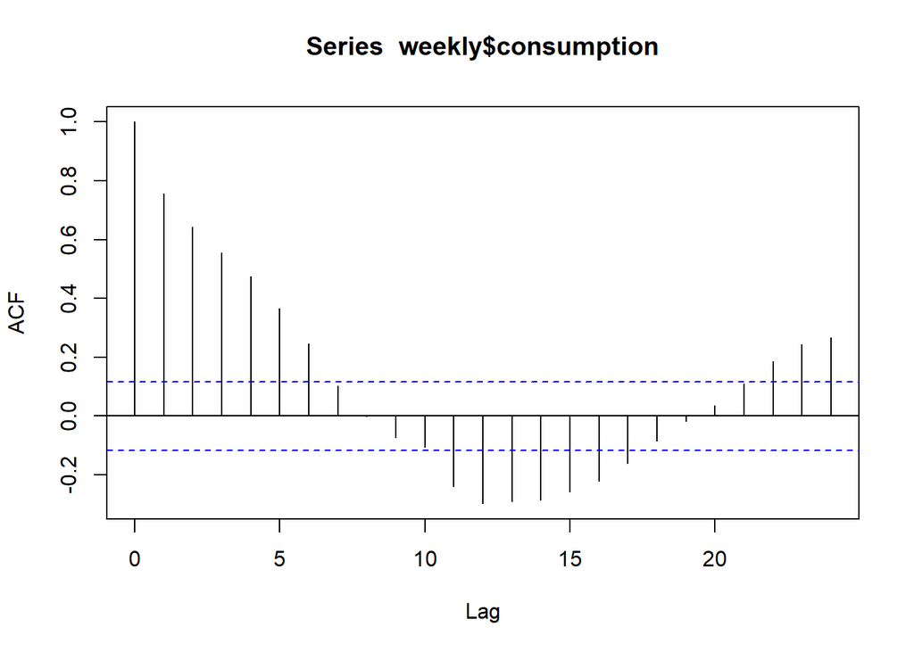

```r
acf(weekly$consumption)
```

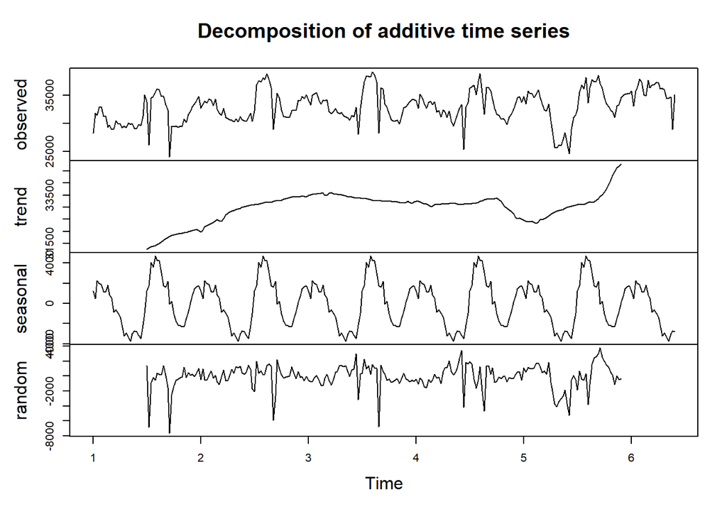

```r
ts_weekly <- ts(weekly$consumption, frequency = 52)
decomposed_weekly <- decompose(ts_weekly, "additive")
plot(decomposed_weekly)
```

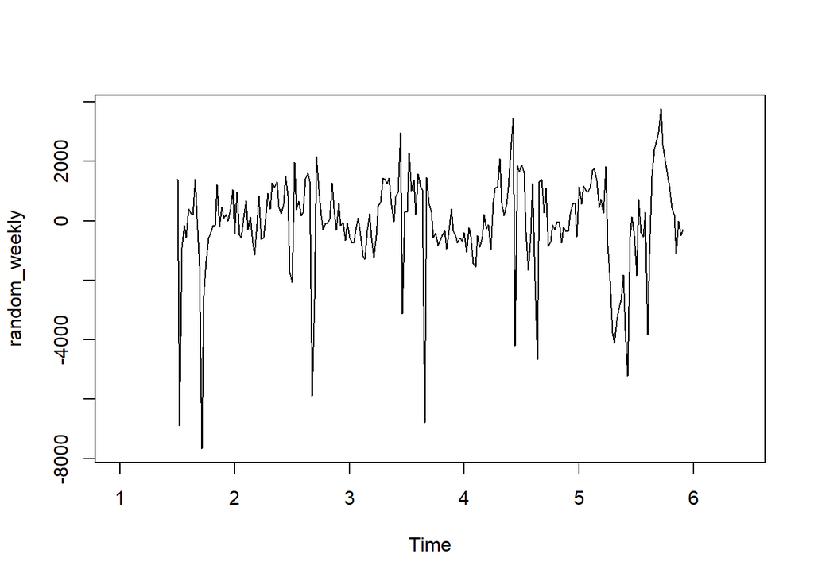

```r
random_weekly <- decomposed_weekly$random
plot(random_weekly)
```

There are times when mean changes, but we can say that constant mean is satisfies in general. There are also times when variance changes, but it may be acceptable.

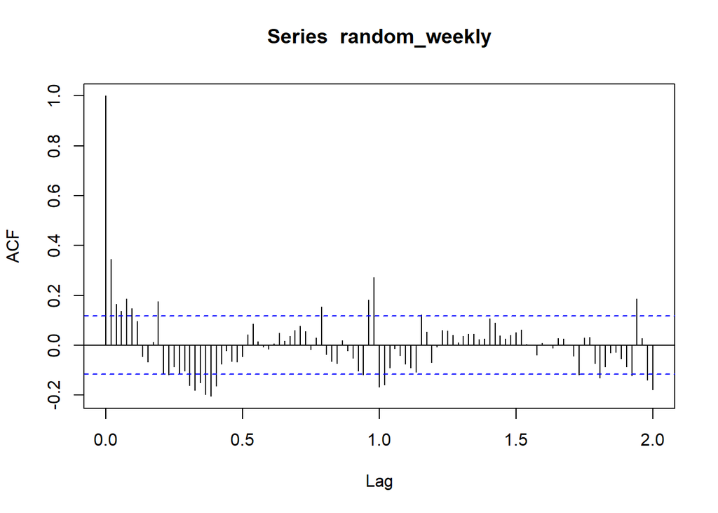

```r
acf(random_weekly, na.action = na.pass, lag.max = 104)
```

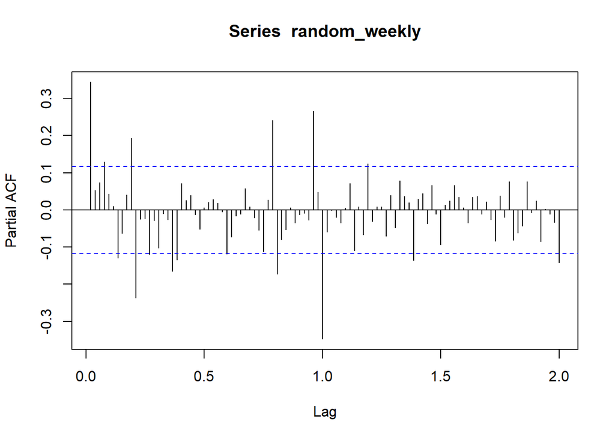

```r
pacf(random_weekly, na.action = na.pass, lag.max = 104)
```

We do not see a very high autocorrelation.

```r
random_weekly %>%
  ur.kpss() %>%
  summary()
```

```
##
## #######################
## # KPSS Unit Root Test #
## #######################
##
## Test is of type: mu with 4 lags.
##
## Value of test-statistic is: 0.0682
##
## Critical value for a significance level of:
##                 10pct  5pct 2.5pct  1pct
## critical values 0.347 0.463  0.574 0.739
```

Again, the stationarity is not rejected.

### 3.1.4 Monthly decomposition

```r
monthly <- daily %>%
  group_by(yearmonth(date)) %>%
  summarise(consumption=mean(consumption)) %>%
  rename(month='yearmonth(date)')
```

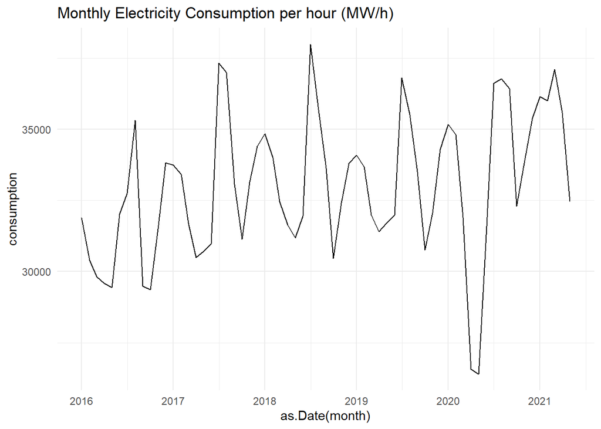

```r
ggplot(monthly,aes(x=as.Date(month),y=consumption))+
  geom_line()+
  theme_minimal()+
  scale_x_date(date_breaks = "1 year", date_labels = "%Y")+
  labs(title="Monthly Electricity Consumption per hour (MW/h)")
```

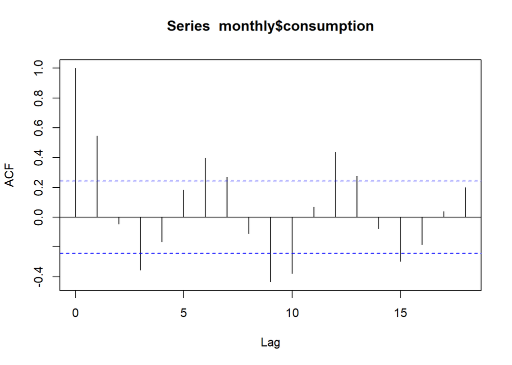

```r
acf(monthly$consumption)
```

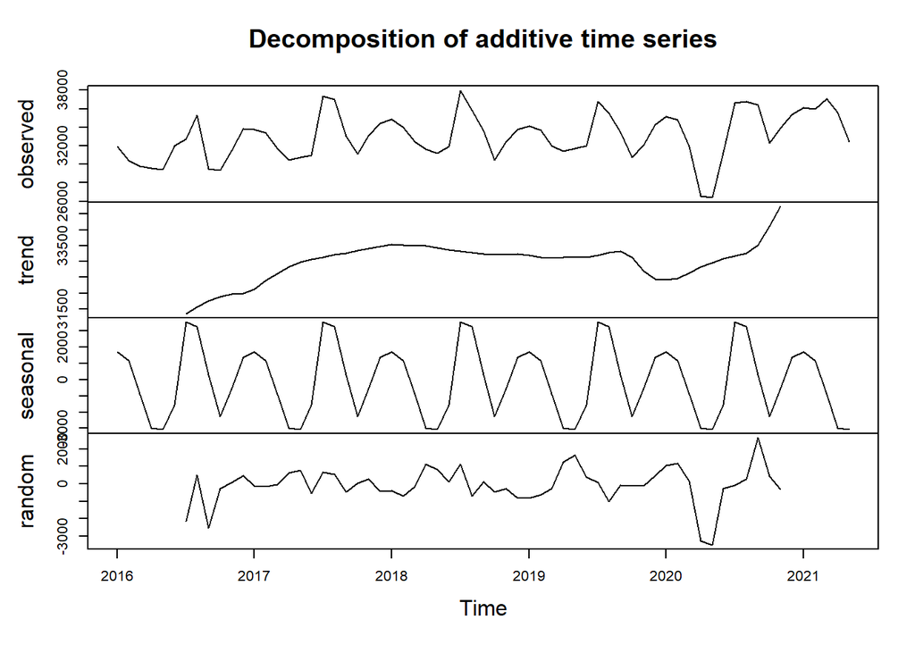

```r
ts_monthly <- ts(monthly$consumption, frequency = 12, start = c(2016,1))
decomposed_monthly <- decompose(ts_monthly, "additive")
plot(decomposed_monthly)
```

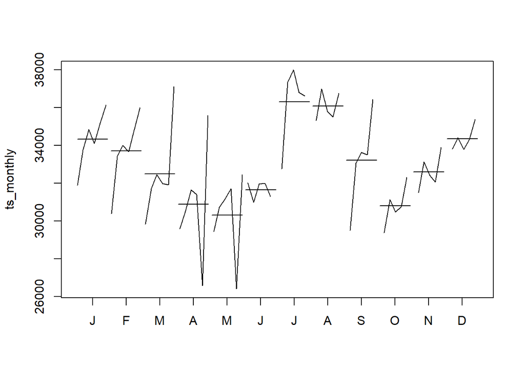

```r
monthplot(ts_monthly)
```

In this plot, we can see the effect of month in electricity consumption. In spring and autumn, we observe relatively lower consumption. Generally the highest electricity consumption is in July and August.

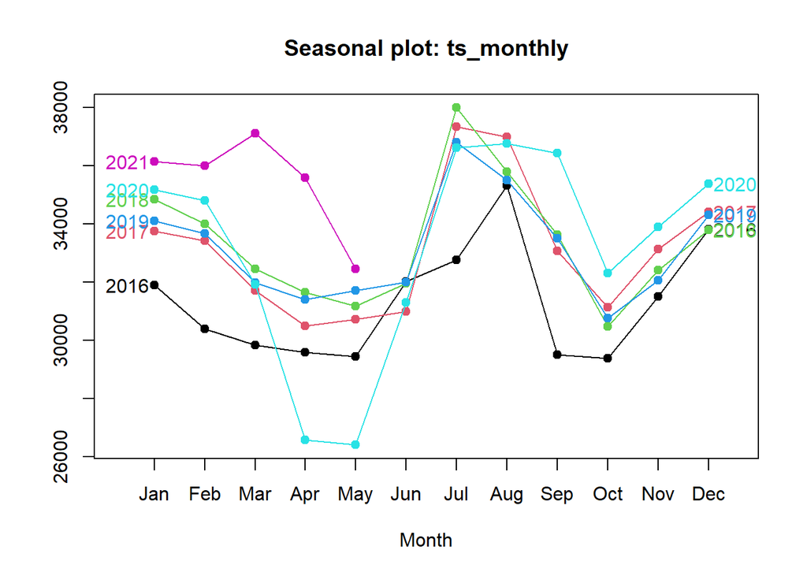

```r
seasonplot(ts_monthly, year.labels=TRUE, year.labels.left=TRUE, col=1:20, pch=19)
```

Again, we see that the pattern within years resembles to each other.

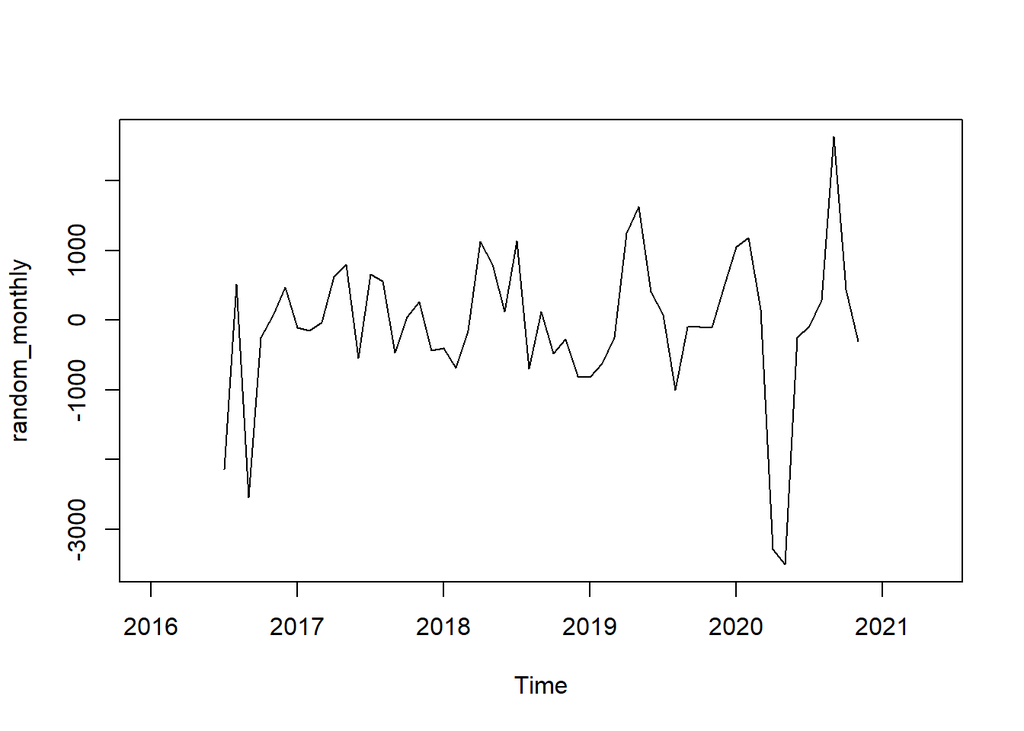

```r
random_monthly <- decomposed_monthly$random
plot(random_monthly)
```

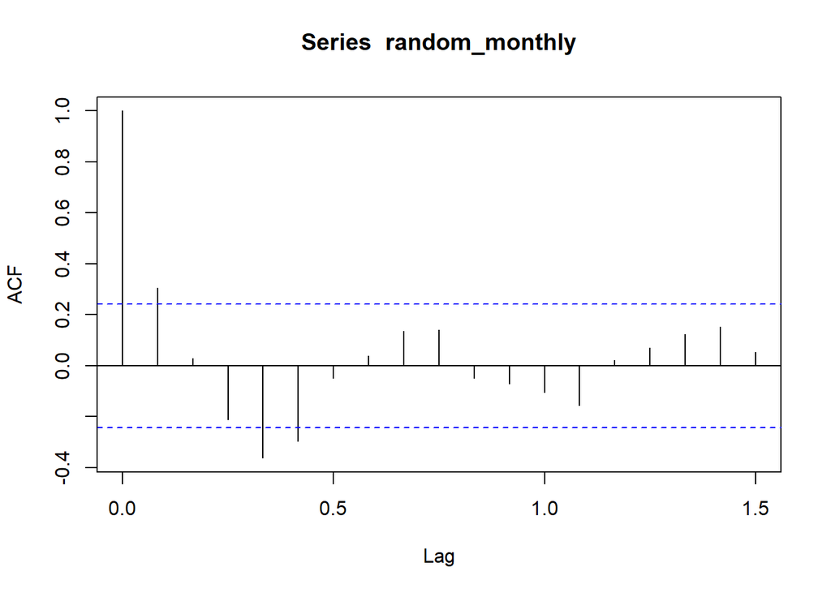

```r
acf(random_monthly, na.action = na.pass)
```

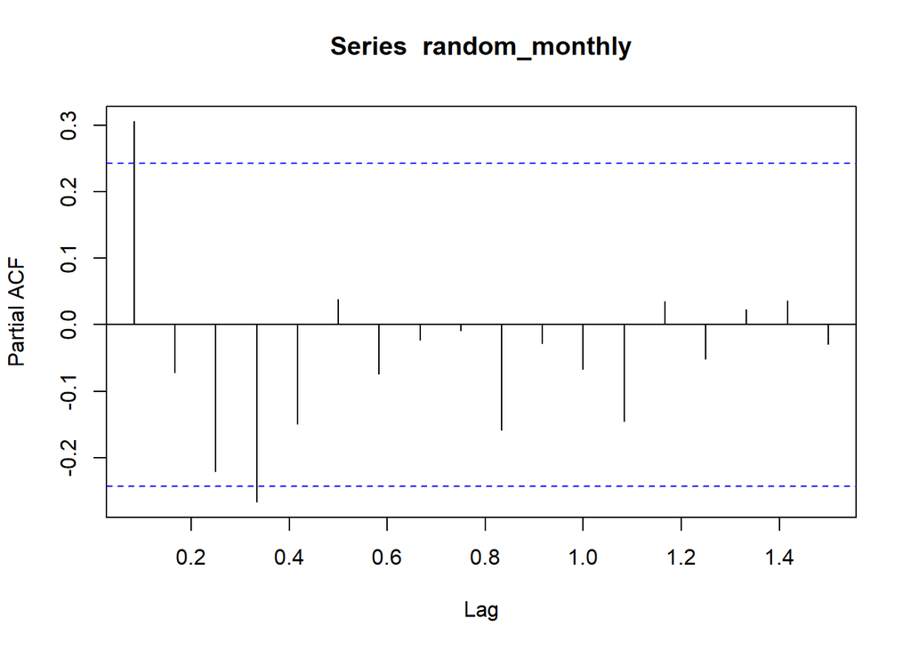

```r
pacf(random_monthly, na.action = na.pass)
```

```r
random_monthly %>%
  ur.kpss() %>%
  summary()
```

```
##
## #######################
## # KPSS Unit Root Test #
## #######################
##
## Test is of type: mu with 3 lags.
##
## Value of test-statistic is: 0.0552
##
## Critical value for a significance level of:
##                 10pct  5pct 2.5pct  1pct
## critical values 0.347 0.463  0.574 0.739
```

Again, the stationarity is not rejected.

## 3.2 Task 2

It is assumed that frequency is 168 (24*7) for the rest of the report. Which means we decided that both the day of week and hour is meaningful to explain hourly electricity consumption.

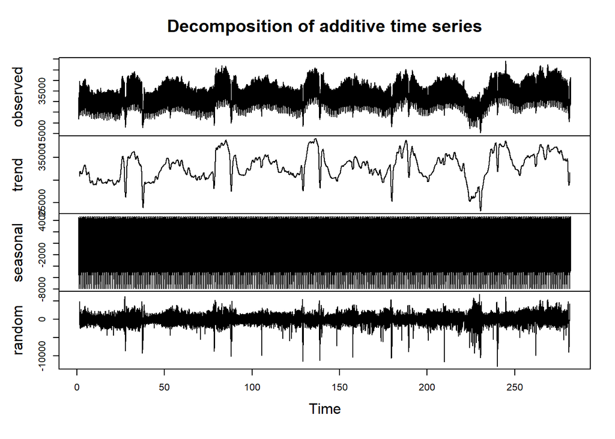

```r
ts_hd <- ts(hourly$consumption, frequency = 24*7)
decomposed_hd <- decompose(ts_hd, type = "additive")
plot(decomposed_hd)
```

- We still see a seasonality in trend.

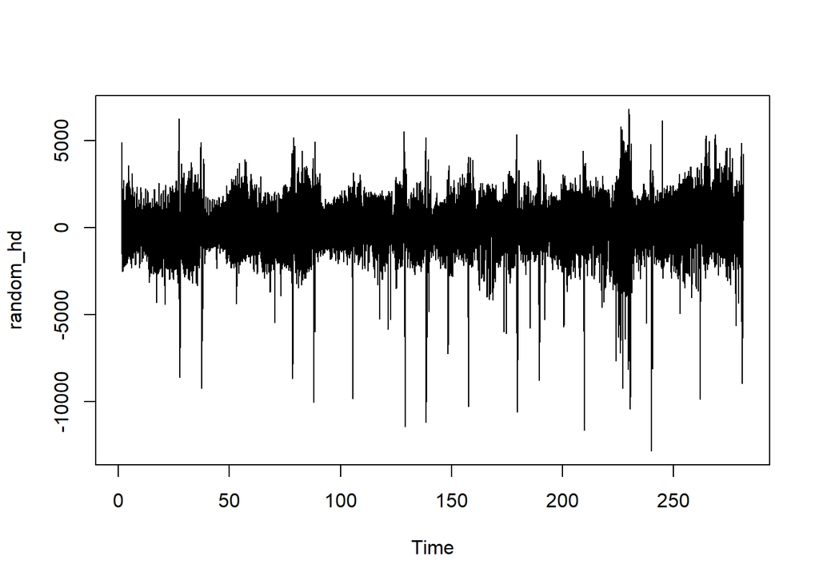

```r
random_hd <- decomposed_hd$random
plot(random_hd)
```

- Random component has constant mean, variance does not change over time significantly.

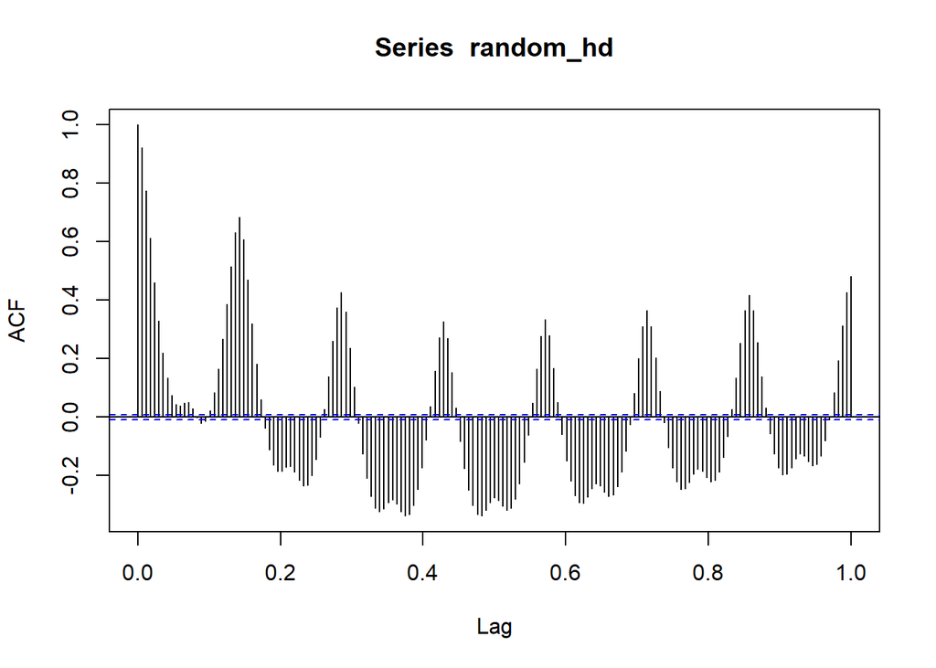

```r
acf(random_hd, na.action=na.pass, lag.max = 168)
```

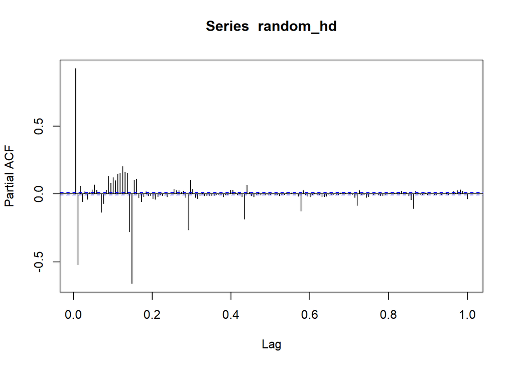

```r
pacf(random_hd, na.action = na.pass,  lag.max = 168)
```

```r
random_hd %>%
  ur.kpss() %>%
  summary()
```

```
##
## #######################
## # KPSS Unit Root Test #
## #######################
##
## Test is of type: mu with 18 lags.
##
## Value of test-statistic is: 0.0042
##
## Critical value for a significance level of:
##                 10pct  5pct 2.5pct  1pct
## critical values 0.347 0.463  0.574 0.739
```

Test statistic is very small, which we like. We fail to reject the null hypothesis and conclude that there is not enough evidence against the stationarity of data. We can continue with this series and apply autoregressive and moving average models.